# Question 5: Googleplay

Grace Grant

June 2023

# 1 App size and ratings linked to number of installs

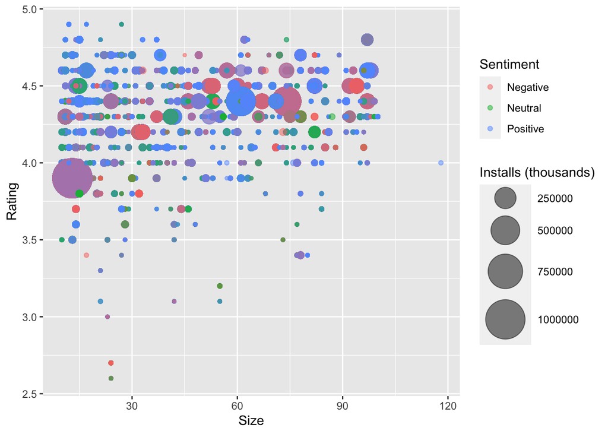

The graph provided above gives an indication of the link between the size of the app and its rating, with most apps having ratings above 4 and sizes below 100M. I would, therefore, suggest an app with a size below 100M. The graph also shows that, while most apps are linked to positive reviewer sentiment, there does not seem to be a link between reviewer sentiment and the number of installations. This can show that, even though it is important to listen to what reviews have to say, this does not necessarily correlate with how many people choose to install an app. If profitability is linked to the number of installations, it would be a better idea to focus on the app rating and keeping those numbers high while also ensuring that apps are not too big in size.

# 2 App ratings and categories

Table 2.1: Top 20 Rated Apps

|  | App | Category | Rating | Installs |
| --- | --- | --- | --- | --- |
| 1 | CDL Practice Test 2018 Edition | AUTO_AND_VEHICLES | 4.9 | 100 |
| 2 | DMV Permit Practice Test 2018 Edition | AUTO_AND_VEHICLES | 4.9 | 100 |
| 3 | Down Dog: Great Yoga Anywhere | HEALTH_AND_FITNESS | 4.9 | 500 |
| 4 | Amino: Communities and Chats | SOCIAL | 4.8 | 10000 |
| 5 | Calculator with Percent (Free) | TOOLS | 4.8 | 1000 |
| 6 | DU Recorder – Screen Recorder, Video Editor, Live | VIDEO_PLAYERS | 4.8 | 50000 |
| 7 | Even - organize your money, get paid early | FINANCE | 4.8 | 100 |
| 8 | Find a Way: Addictive Puzzle | FAMILY | 4.8 | 500 |
| 9 | FreePrints – Free Photos Delivered | PHOTOGRAPHY | 4.8 | 1000 |
| 10 | Fuzzy Seasons: Animal Forest | FAMILY | 4.8 | 100 |
| 11 | GoodRx Drug Prices and Coupons | MEDICAL | 4.8 | 1000 |
| 12 | GPS Speedometer and Odometer | MAPS_AND_NAVIGATION | 4.8 | 1000 |
| 13 | Home Workout - No Equipment | HEALTH_AND_FITNESS | 4.8 | 10000 |
| 14 | Home Workout for Men - Bodybuilding | HEALTH_AND_FITNESS | 4.8 | 1000 |
| 15 | 1800 Contacts - Lens Store | MEDICAL | 4.7 | 1000 |
| 16 | Abs Training-Burn belly fat | HEALTH_AND_FITNESS | 4.7 | 100 |
| 17 | Ada - Your Health Guide | MEDICAL | 4.7 | 1000 |
| 18 | ASOS | SHOPPING | 4.7 | 10000 |
| 19 | Associated Credit Union Mobile | FINANCE | 4.7 | 50 |
| 20 | Backgrounds (HD Wallpapers) | PERSONALIZATION | 4.7 | 10000 |